# Dimensionality reduction

### 2.3. Quality of representation

- Indicate the contribution of a component to the squared distance of the observation to the origin
- Components with a large value of cos2 contribute a relatively large portion to the total distance and therefore these components are importance for that observation
- The closer a variable is to the circle of correlation, the better its representation on the factor map (the more important it is to interpret components)

```r
cos2 <- res.var$cos2
cos2[,1:4]
```

```
##                           Dim.1       Dim.2        Dim.3        Dim.4
## flower.Aber        2.107596e-01 0.238566892 6.102598e-02 0.0059966822
## flower.Ark         4.722909e-01 0.258279461 9.646016e-03 0.0223808769
## flower.Fari        3.518660e-01 0.102112587 1.977767e-02 0.0047054007
## culm               4.073276e-02 0.248894835 2.418555e-02 0.2329801128
## leaf.length        2.752435e-01 0.203802082 9.966248e-05 0.1406463348
## leaf.width         1.024397e-01 0.354401505 1.251640e-01 0.0122285256
## plant.height       3.089822e-01 0.011775417 4.535630e-02 0.3952823766
## panicle.length     4.796810e-01 0.076442412 6.389797e-02 0.0811492028
## pri.panicle.branch 1.764496e-01 0.229473731 2.296216e-01 0.0844487732
## seed.panicle       3.568383e-01 0.083398291 3.163578e-01 0.0508388870
## flor.panicle       3.705855e-01 0.180779757 2.514966e-01 0.0539344512
## panicle.fertility  2.360992e-05 0.127957114 3.131103e-02 0.0002161498
## seed.length        2.385306e-04 0.362541930 5.264177e-01 0.0389243559
## seed.width         6.156933e-01 0.044404031 2.271982e-01 0.0922753172
## seed.volum         6.488321e-01 0.265903940 1.376994e-02 0.0496779696
## seed.surface       4.490149e-01 0.463220686 4.055427e-02 0.0103593003
## brown.length       4.689479e-03 0.377808749 4.937558e-01 0.0565790411
## brown.width        5.924426e-01 0.021383762 2.573556e-01 0.1021557803
## brown.surface      4.226216e-01 0.490257715 2.863217e-02 0.0130305959
## brown.volume       6.273443e-01 0.255950238 2.864393e-02 0.0589541125
## straighhead        4.003805e-01 0.009714048 2.187699e-02 0.1806703572
## blast              1.646400e-01 0.050056142 5.461367e-03 0.0014897142
## amylose            3.667694e-01 0.018380757 2.465382e-02 0.0509314682
## alkali.spreading   1.574376e-03 0.053244241 1.109748e-01 0.0424933525
## protein            1.465763e-01 0.047698507 9.378891e-02 0.0130170418
```

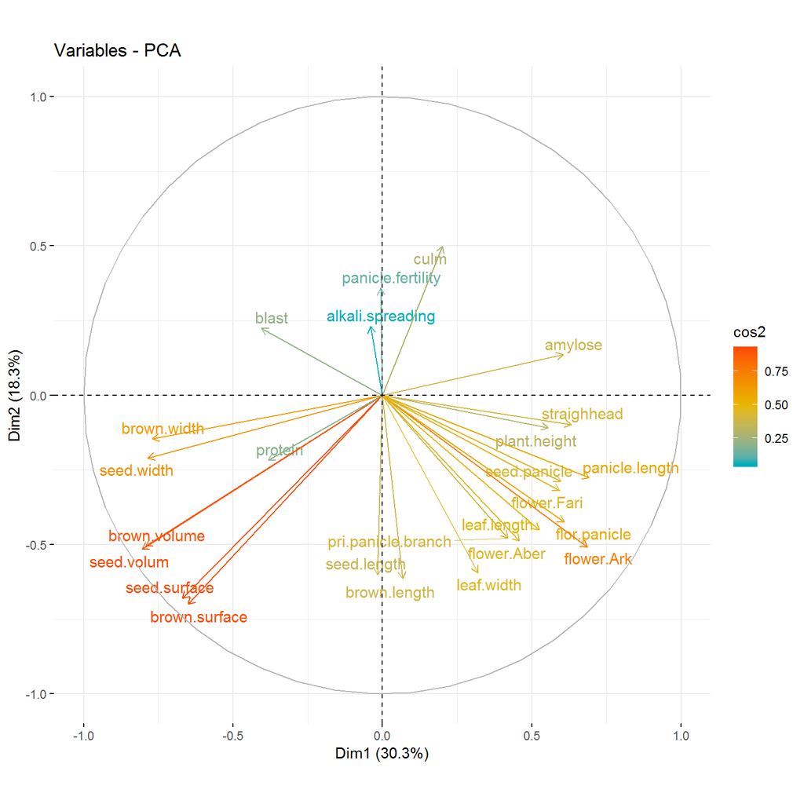

```r
fviz_pca_var(res, axes = c(1,2), col.var = "cos2", gradient.cols = c("#00AFBB", "#E7B800", "#FC4E07"),repel = TRUE)
```

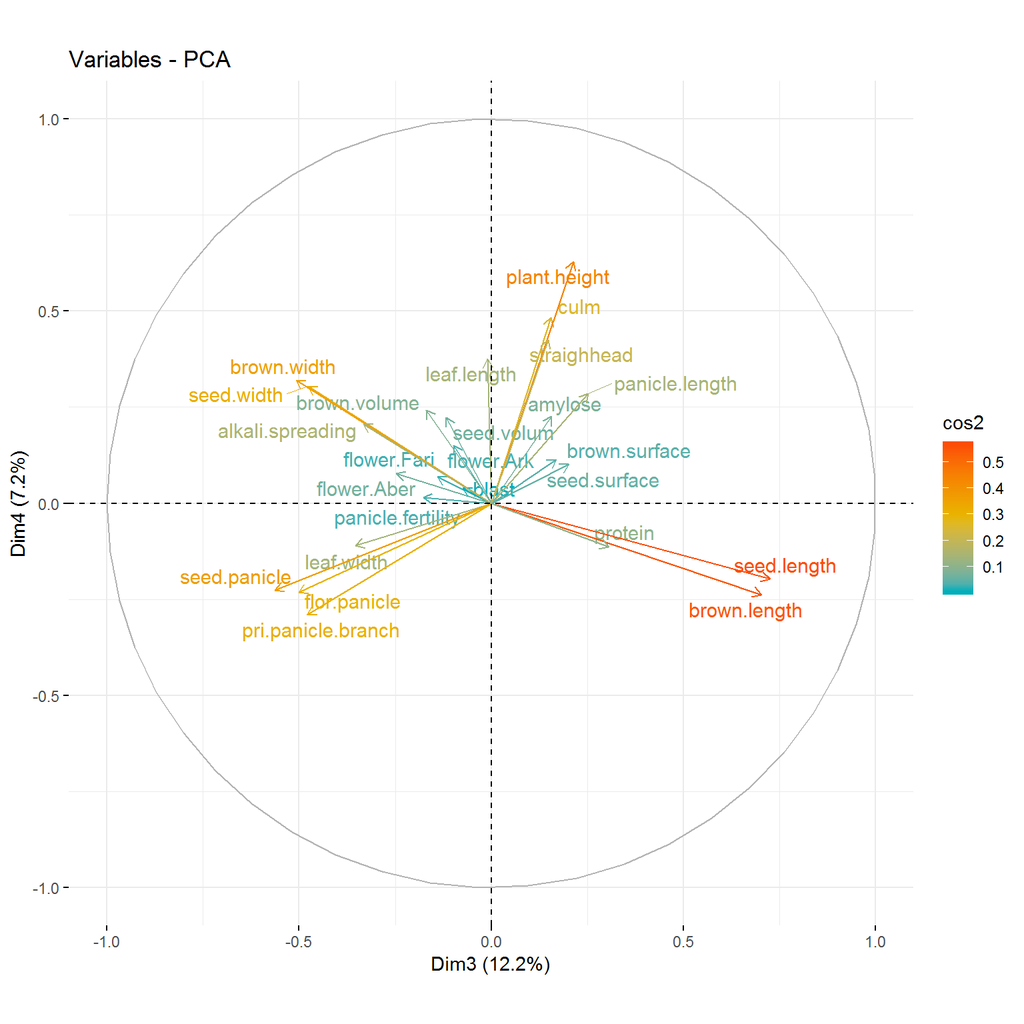

```r
fviz_pca_var(res, axes = c(3,4), col.var = "cos2", gradient.cols = c("#00AFBB", "#E7B800", "#FC4E07"),repel = TRUE)
```

### 2.4. Contributions of the variables

- Contributions of the variables in accounting for the variability in a given principal component are expressed in percentage
- Variables that are correlated with PC1 and PC2 are the most important in explaining the variability in the data set
- Variables that do not correlated with any PC or correlated with the last dimension are variables with low contribution and migh be removed to simplify the overall analysis

```r
contrib <- res.var$contrib
contrib[,1:4]
```

```
##                           Dim.1      Dim.2        Dim.3       Dim.4
## flower.Aber        2.7780105439  5.2129260  2.000180516  0.33400886
## flower.Ark         6.2252394069  5.6436654  0.316156703  1.24659120
## flower.Fari        4.6379262981  2.2312625  0.648230563  0.26208585
## culm               0.5368962143  5.4386020  0.792702899 12.97674622
## leaf.length        3.6279689083  4.4532800  0.003266526  7.83385230
## leaf.width         1.3502523773  7.7440286  4.102362135  0.68111596
## plant.height       4.0726771371  0.2573047  1.486592709 22.01681088
## panicle.length     6.3226483687  1.6703434  2.094312581  4.51992489
## pri.panicle.branch 2.3257723219  5.0142313  7.526051827  4.70370747
## seed.panicle       4.7034653934  1.8223364 10.368905513  2.83167231
## flor.panicle       4.8846670420  3.9502191  8.243024342  3.00409197
## panicle.fertility  0.0003112011  2.7959914  1.026246638  0.01203932
## seed.length        0.0031440590  7.9219050 17.253805175  2.16804551
## seed.width         8.1154189783  0.9702726  7.446621023  5.13963771
## seed.volum         8.5522196829  5.8102680  0.451321978  2.76701044
## seed.surface       5.9184402410 10.1218369  1.329202198  0.57700208
## brown.length       0.0618117524  8.2555003 16.183283216  3.15139283
## brown.width        7.8089527836  0.4672567  8.435057236  5.68996907
## brown.surface      5.5705509657 10.7126231  0.938444592  0.72579043
## brown.volume       8.2689902163  5.5927696  0.938830179  3.28368180
## straighhead        5.2773933846  0.2122617  0.717037563 10.06314808
## blast              2.1701103393  1.0937769  0.179001123  0.08297551
## amylose            4.8343661555  0.4016380  0.808050790  2.83682899
## alkali.spreading   0.0207517645  1.1634401  3.637297405  2.36683485
## protein            1.9320144638  1.0422602  3.074014571  0.72503548
```

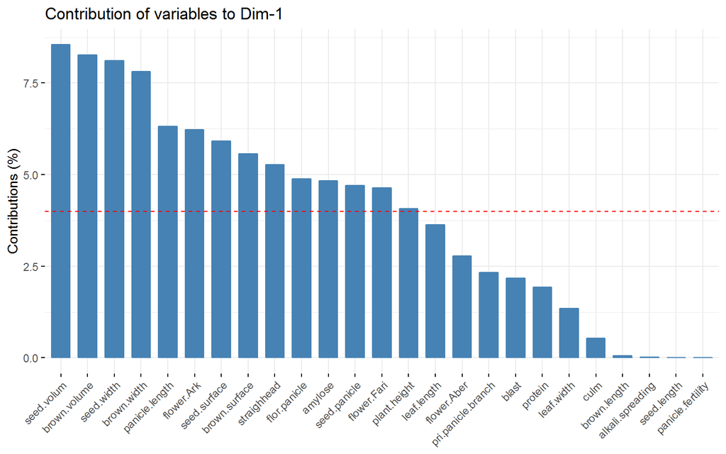

```r
fviz_contrib(res, choice = "var", axes = 1)
```

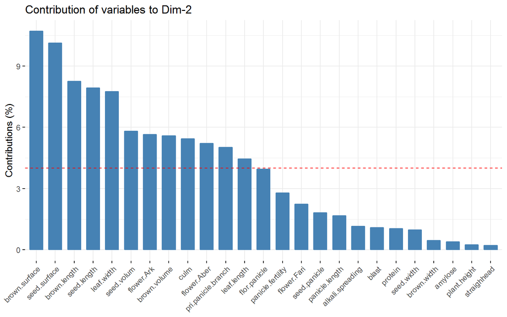

```r
fviz_contrib(res, choice = "var", axes = 2)
```

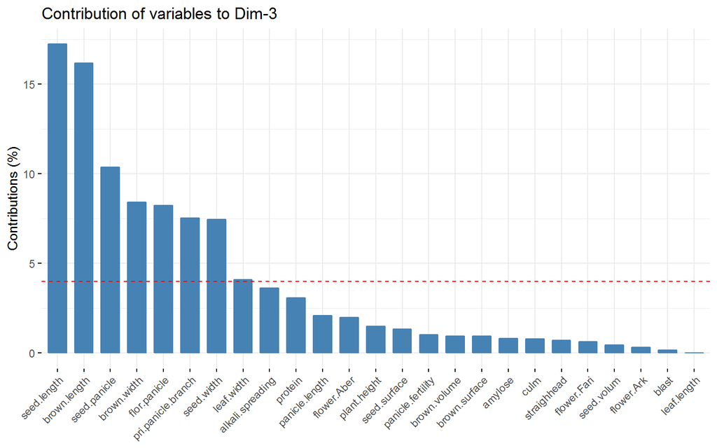

```r
fviz_contrib(res, choice = "var", axes = 3)
```